# ToothGrowth data analysis

Jose Gonzalez

10 novembre 2016

# Introduction

In this repport, we analyze the toothgrowth per supplement and dosis. Our objective is to identify which supplement is most efficient, at different dosis, for toothGrowth

# Exploratory analysis

We will start with some explanatory analysis to get a better view on the data and the impact of each variable

## Per supplement or per dose

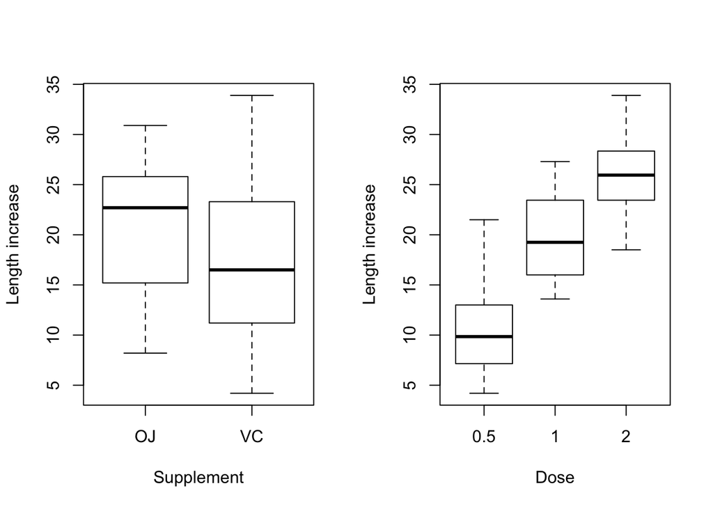

```r
par(mfrow=c(1,2))
boxplot(len~supp,data =ToothGrowth,
        xlab="Supplement",
        ylab="Length increase")
boxplot(len~dose,data =ToothGrowth,
        xlab="Dose",
        ylab="Length increase")
```

## Per dose and supplement

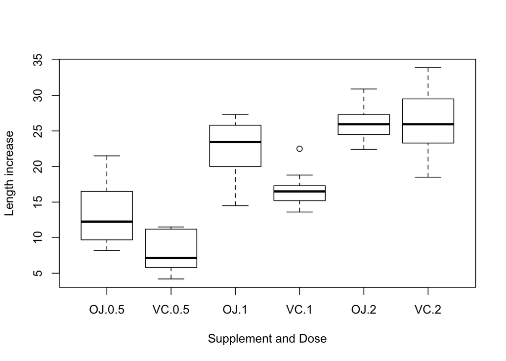

```r
boxplot(len~supp+dose,data =ToothGrowth,
        xlab="Supplement and Dose",
        ylab="Length increase")
```

# Data Summary

Mean growth per supplement and dose

```r
aggregate(ToothGrowth$len~ToothGrowth$supp+ToothGrowth$dose,FUN=mean)
```

```
##   ToothGrowth$supp ToothGrowth$dose ToothGrowth$len
## 1               OJ              0.5           13.23
## 2               VC              0.5            7.98
## 3               OJ              1.0           22.70
## 4               VC              1.0           16.77
## 5               OJ              2.0           26.06
## 6               VC              2.0           26.14
```

# Hypothesis test

To confirm the observations in the exploratory data analysis and data summary sections, that is: OJ supplement appears to be more efficient at Toothgrowth than VC component, at lower dosis, we will compare the toothgrowth of the two supplements at the different dosis with a t-test

## T-test of difference between supplements per dosis

Comparison of growth difference from VC to OJ supplement per dose using a T-test:

```r
t_result=NULL
tmp_result=NULL
t_result=data.frame(dose=NULL,
                    mean=NULL,
                    low_interval=NULL,
                    high_interval=NULL,
                    p.value=NULL)
for(i in unique(ToothGrowth$dose)){
  tmp_result<-t.test(
    ToothGrowth[ToothGrowth$supp=="OJ" &
                  ToothGrowth$dose==i,]$len-
      ToothGrowth[ToothGrowth$supp=="VC"
                  & ToothGrowth$dose==i,]$len)

  t_result=rbind(t_result,
                 data.frame(
                   dose=i,
                   mean=tmp_result$estimate,
                    low_interval=tmp_result$conf.int[1],
                    high_interval=tmp_result$conf.int[2],
                    p.value=tmp_result$p.value
                    ))
}
row.names(t_result)=rep(NULL,3)
```

Summary of T-test per dosis:

```r
xt_t_result<-xtable(t_result)
print(xt_t_result,type="html",row.names=FALSE)
```

|  | dose | mean | low_interval | high_interval | p.value |
| --- | --- | --- | --- | --- | --- |
| 1 | 0.50 | 5.25 | 1.26 | 9.24 | 0.02 |
| 2 | 1.00 | 5.93 | 1.95 | 9.91 | 0.01 |
| 3 | 2.00 | -0.08 | -4.33 | 4.17 | 0.97 |

The T-test is conclusive, for 0.5 and 1 dosis, OJ yields a higher growth. No conclusion can be taken for dosis 2.0

## Quantiles at maximum dosis per component

Quantiles at maximum dosis for OJ supplement:

```r
quantile(ToothGrowth[ToothGrowth$supp=="OJ" &
                  ToothGrowth$dose==2,]$len)
```

```
##     0%    25%    50%    75%   100%
## 22.400 24.575 25.950 27.075 30.900
```

Quantiles at maximum dosis for VC supplement:

```r
quantile(ToothGrowth[ToothGrowth$supp=="VC" &
                  ToothGrowth$dose==2,]$len)
```

```
##     0%    25%    50%    75%   100%
## 18.500 23.375 25.950 28.800 33.900
```

The quantiles show that despite the fact that the means of growth at maximum doses are similar, the OJ growth is more predictable as the distribution is less spread than the VC one.

# Conclusion

We see that the OJ supplement is, at doses 0.5 and 1.0, more efficient at tooth growth than supplement VC. At a dose of 2.0, no conclusive difference between the two components was found, but the OJ supplement provides a more concentrated growth than the VC.